# Tutorial 6: Stratified Sampling Solutions

Lovnesh Bhardwaj

October 21, 2024

## Question (a)

**What is the value of the parameter that the pollster tries to estimate?**

The pollster is trying to estimate the true fraction of T voters in the entire country, denoted as $p = \frac{(24+16)}{100} = 0.4$.

## Question (b)

**Is the estimator unbiased?**

To check whether the estimator $\hat{p}_{strat1}$ is unbiased, we need to compute its expected value and check if it is equal to the true proportion $p$.

The stratified estimator is given by:

$$\hat{p}_{strat1} = 0.5 \times \frac{X_r}{5} + 0.5 \times \frac{X_b}{5}$$

Where: - $X_r$ is the number of T supporters in the Red County sample - $X_b$ is the number of T supporters in the Blue County sample

The expected value of $\hat{p}_{strat1}$ is:

$$E[\hat{p}_{strat1}] = 0.5 \times E\left[\frac{X_r}{5}\right] + 0.5
\times E\left[\frac{X_b}{5}\right]$$

Since the expected value of the number of T supporters in the Red County is $0.8$ (as 16 out of 20 support T) and in the Blue County is $0.3$ (as 24 out of 80 support T), the expected value of the estimator becomes:

$$E[\hat{p}_{strat1}] = \frac{(5 \times 0.8 + 5 \times 0.3)}{10} = 0.55$$

Thus, the expected value is $0.55$, which is different from the true proportion $p = 0.4$, meaning that this estimator is not unbiased.

## Question (c)

**Find the values of** $c$ and $w$ to make the estimators unbiased.

For the estimator $\hat{p}_{strat2a} = c \times \hat{p}_{strat1}$, the constant $c$ is calculated as:

$$c = \frac{0.4}{0.55} = 0.73$$

For the estimator $\hat{p}_{strat2b} = w \times \frac{X_r}{5} + (1 - w) \times \frac{X_b}{5}$, we can calculate $w$ by solving the equation:

$$0.4 = w \times 0.8 + (1 - w) \times 0.3$$

This gives:

$$w = \frac{0.4 - 0.3}{0.5} = 0.2$$

Thus, $w = 0.2$.

## Question (d)

**Determine the standard deviation of** $\hat{p}_{strat2b}$.

To calculate the variance of $\hat{p}_{strat2b}$, we start by expressing the estimator as:

$$\hat{p}_{strat2b} = w \times \frac{X_r}{5} + (1 - w) \times
\frac{X_b}{5}$$

Given that $w = 0.2$, the estimator becomes:

$$\hat{p}_{strat2b} = 0.2 \times \frac{X_r}{5} + 0.8 \times \frac{X_b}{5}$$

### Variance Calculation:

The variance of a weighted sum of two independent random variables is given by:

$$V(\hat{p}_{strat2b}) = V\left( 0.2 \times \frac{X_r}{5} + 0.8 \times
\frac{X_b}{5} \right)$$

Using the fact that $V(aX) = a^2 \times V(X)$, we expand the variance as:

$$V(\hat{p}_{strat2b}) = 0.04^2 \times V\left( X_r \right) + 0.16^2 \times
V\left( X_b \right)$$

Next, we calculate the variances of $X_r$ and $X_b$ under a binomial distribution:

- For $X_r$ (the number of T supporters in the Red County sample), the variance is:

$$V(X_r) = 5 \times 0.8 \times 0.2$$

- For $X_b$ (the number of T supporters in the Blue County sample), the variance is:

$$V(X_b) = 5 \times 0.3 \times 0.7$$

Substituting these into the equation for the variance of $\hat{p}_{strat2b}$:

$$V(\hat{p}_{strat2b}) = 0.04^2 \times 5 \times 0.8 \times 0.2 + 0.16^2
\times 5 \times 0.3 \times 0.7$$

```r
# Standard deviation
v <- 0.04^2 * 5 * 0.8 * 0.2 + 0.16^2 * 5 * 0.3 * 0.7
std_dev <- sqrt(v)
std_dev
```

```
## [1] 0.1678094
```

## Question (f)

**Voter Poll Simulation**

1. **Simple Random Sampling**: We sample 10 individuals from the entire population with replacement.
2. **Proportional Stratified Random Sampling**: We sample 2 individuals from the Red County (where 80% support T) and 8 from the Blue County (where 30% support T).
3. **Weighted Stratified Random Sampling**: We sample 5 individuals from both Red County and Blue County, using the weights found in previous parts.

We will then compute the mean and standard deviation for each sampling scheme.

### Simulation Code:

```r
# Set the number of simulations
n <- 1000000

# Simple Random Sampling: sample 10 individuals from the population with p = 0.4 (T supporters)
p.srs <- rbinom(n, 10, 0.4) / 10

# Proportional Stratified Random Sampling: sample 2 from Red County (p = 0.8) and 8 from Blue County (p = 0.3)
p.str <- (rbinom(n, 2, 0.8) + rbinom(n, 8, 0.3)) / 10

# Weighted Stratified Random Sampling: sample 5 from Red County (p = 0.8) and 5 from Blue County (p = 0.3)
p.str2b <- 0.2 * rbinom(n, 5, 0.8) / 5 + 0.8 * rbinom(n, 5, 0.3) / 5

# Calculate the mean and standard deviation for each sampling method
mean_srs <- mean(p.srs)
mean_str <- mean(p.str)
mean_str2b <- mean(p.str2b)

sd_srs <- sd(p.srs)
sd_str <- sd(p.str)
sd_str2b <- sd(p.str2b)

# Output the results
mean_srs
```

```
## [1] 0.4001189
```

```r
mean_str
```

```
## [1] 0.4000938
```

```r
mean_str2b
```

```
## [1] 0.4000144
```

```r
sd_srs
```

```
## [1] 0.1550635
```

```r
sd_str
```

```
## [1] 0.1415909
```

```r
sd_str2b
```

```
## [1] 0.1677687
```

## Question (g)

**What is the approximate distribution of** $\hat{p}_{strat2b}$?

Based on the Central Limit Theorem, we know that the sum of a large number of independent random variables tends to follow a normal distribution. In this case, $\hat{p}_{strat2b}$, being a weighted sum of two independent binomially distributed random variables (representing samples from Red and Blue counties), will approximately follow a normal distribution as the number of samples becomes large.

Therefore, the approximate distribution of $\hat{p}_{strat2b}$ is:

$$\hat{p}_{strat2b} \sim N(0.4, 0.17^2)$$

This means that $\hat{p}_{strat2b}$ is normally distributed with a mean of 0.4 and a standard deviation of 0.17. The mean reflects the true proportion of T supporters, and the standard deviation indicates the spread or variability in the estimator.

## Question (h)

**Make a histogram of the values for** $\hat{p}_{strat2b}$ and superimpose the density of the approximate distribution.

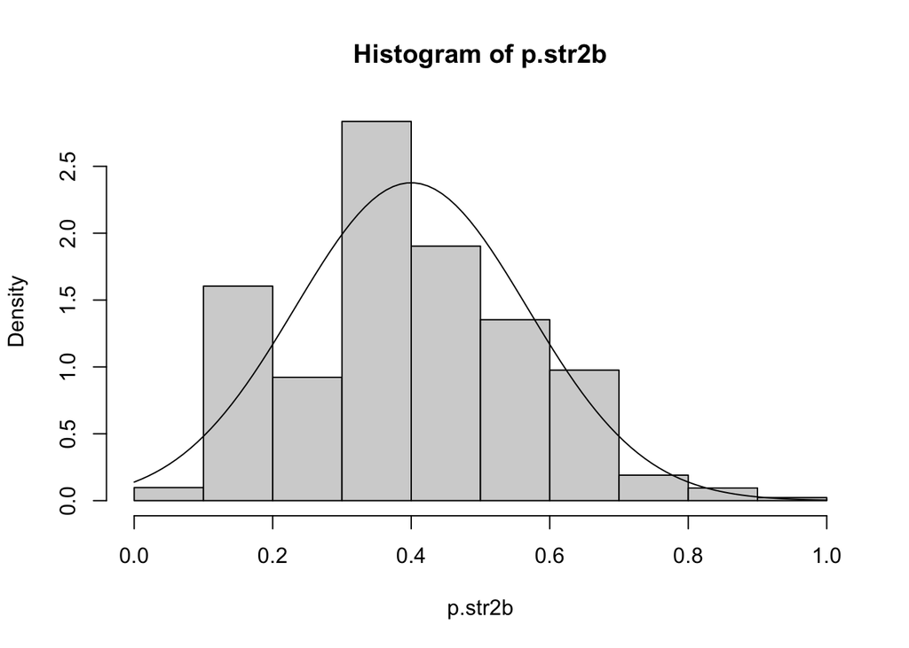

```r
# Histogram with density plot
hist(p.str2b,breaks=10,prob=TRUE)
x<-seq(0,1,length=100)
lines(x,dnorm(x,0.4,sqrt(v)))
```